# Motor Trend Review: Miles per Galon and transmission, does it matter?

## Introduction

This month we will be reviewing the effect of automatic and manual *transmission* in fuel consumption or *miles per galon (mpg)* in several car models. For more information about this data please visit the [dataset](https://stat.ethz.ch/R-manual/R-devel/library/datasets/html/mtcars.html) web-page.

## The data

First we will be loading the data and some exploratory analysis tools that we can use to see trends and possible correlations between *mpg* and *transmission*:

```r
data(mtcars)
library(ggplot2)
library(gridExtra)
```

## Data analysis

Taking a first look to the data, we clearly see that the type of transmission installed can affect fuel consumption:

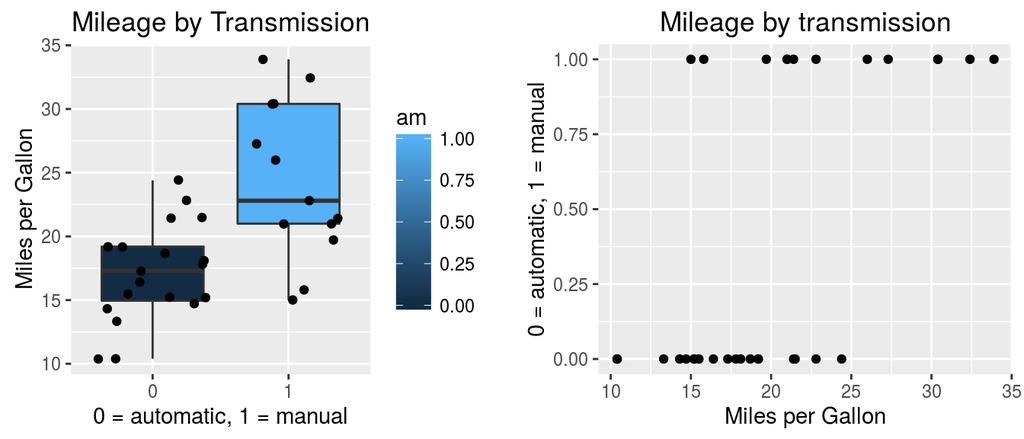

As we can see it seems to be an effect of the kind of transmission and the fuel consumption. To further address this issue we will be performing a littel inferential analysis using t-test:

```
##        Transmission Type
## auto            17.14737
## manual          24.39231
```

The means between auto and manual transmission are pretty different, but is this different significant so we can assume that manual transmission is better for mpg?:

```
## [1] 0.0006868192
```

We see a p value way lower than the type one error of .05, so we could reject the null hypothesis and state that **manual transmission represents a more economic fuel consumption (higher milles per gallon)**. **BUT** this interpretation assumes that all cars are the same, and we know that cars are not only gears. So we have to consider other variables.

## Correlation analysis

For starters we have to analyze the possible correlations between *mpg* and the other 10 variables:

```
##         wt        cyl       disp         hp       carb       qsec
## -0.8676594 -0.8521620 -0.8475514 -0.7761684 -0.5509251  0.4186840
##       gear         am         vs       drat        mpg
##  0.4802848  0.5998324  0.6640389  0.6811719  1.0000000
```

So it seems that other variables have also a possible effect on *mpg*. We can also see that if we plot some of these variables together with *mpg* and *am* (see supplementary Inofrmation, **3**).

### Linear model

Our first linear model (fit) analysis will be just using the simplest *linear regression model* for *mpg* with only *am* as a predictor:

```
##              Estimate Std. Error   t value     Pr(>|t|)
## (Intercept) 17.147368   1.124603 15.247492 1.133983e-15
## am           7.244939   1.764422  4.106127 2.850207e-04
```

```
## [1] 0.3597989
```

### Multivariate regression model

Next question is, can we do better? Is there any combination of variables as predictors (including *am*) that will give us a better model?. To address this we will be using the *step()* function to find the best model (fit3 model):

```r
fit3 <- step(lm(mpg ~ ., mtcars), trace = 0)
summary(fit3)$coef; summary(fit3)$r.squared
```

```
##              Estimate Std. Error   t value     Pr(>|t|)
## (Intercept)  9.617781  6.9595930  1.381946 1.779152e-01
## wt          -3.916504  0.7112016 -5.506882 6.952711e-06
## qsec         1.225886  0.2886696  4.246676 2.161737e-04
## am           2.935837  1.4109045  2.080819 4.671551e-02
```

```
## [1] 0.8496636
```

This shows that weight of the vehicle as well as acceleration speed explain most of the variation in *mpg*. So we actually have a model which includes only 1 predictor (*am*) and 2 confounders (*wt* and *qsec*) that explains up to 85% of the variance. Including all 9 confounders gave us a model that explained the 87% of the variance but this actually shows that we also **included unnecessary variables in the analysis**.

Finally we will perform an analysis of variance or ANOVA comparing the linear model (fit) and the best fitted model (fit3):

```
## Analysis of Variance Table
##
## Model 1: mpg ~ am
## Model 2: mpg ~ wt + qsec + am
##   Res.Df    RSS Df Sum of Sq      F   Pr(>F)
## 1     30 720.90
## 2     28 169.29  2    551.61 45.618 1.55e-09 ***
## ---
## Signif. codes:  0 '***' 0.001 '**' 0.01 '*' 0.05 '.' 0.1 ' ' 1
```

In summary we can state that we cannot answer the question *Is an automatic or manual transmission better for MPG?* just by including *mpg* and *am* but we have to consider in the context the weight and the acceleartion. So we conclude that in **our model “fit3” where *wt* and *qsec* are included as confounders, cars with manual transmission have 2.94 increased in Milles per Gallon (thus more economic) than cars with automatic transmission**.

## Supplementary Information

1. Figure 1 R code

```r
g1 <- qplot(mpg, am, data = mtcars, main = "Mileage by transmission", xlab = "Miles per Gallon",
            ylab = "0 = automatic, 1 = manual")
g4 <- qplot(mpg, factor(am),data=mtcars, geom=c("boxplot", "jitter"),
            fill = am, main="Mileage by Transmission",
            xlab="0 = automatic, 1 = manual", ylab="Miles per Gallon")
grid.arrange(g4, g1, ncol = 2, nrow = 1)
```

2. T-test and data manipulation

```r
#grouping the data and t-test
manual <- mtcars[mtcars$am == "1",]$mpg
auto <- mtcars[mtcars$am == "0",]$mpg
matrix(c(mean(auto), mean(manual))) -> tab
rownames(tab) <- c("auto", "manual")
colnames(tab) <- "Transmission Type"
print(tab)
t.test(manual, auto, alternative = "greater")$p.value
```

3. Relation between different variables and *mp* and *am*

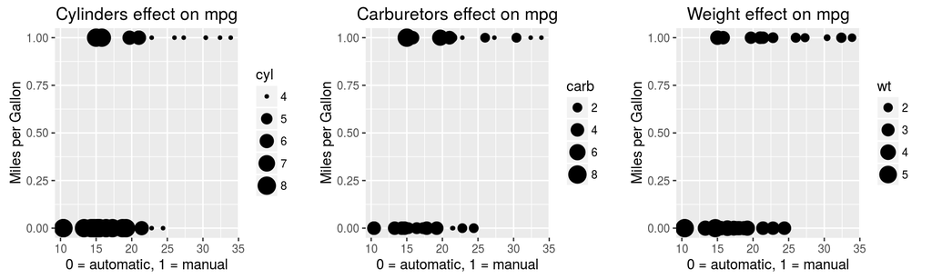

```r
g3bis <- qplot(mpg, am, data = mtcars, size = cyl, ylab = "Miles per Gallon",
               xlab="0 = automatic, 1 = manual", main = "Cylinders effect on mpg")
g3bis2 <- qplot(mpg, am, data = mtcars, size = carb, main = "Carburetors effect on mpg",
                ylab = "Miles per Gallon", xlab="0 = automatic, 1 = manual")
g3bis3 <- qplot(mpg, am, data = mtcars, size = wt, main = "Weight effect on mpg",
                ylab = "Miles per Gallon", xlab="0 = automatic, 1 = manual")
grid.arrange(g3bis, g3bis2, g3bis3, ncol = 3, nrow = 1)
```

Different trends in the data depending on the variables we choose to include in our anaiysis, supporting the idea that we can not assume a t-test including just *mpg* and *am* as the only factors.

4. Residuals vs Fitted in our three different models

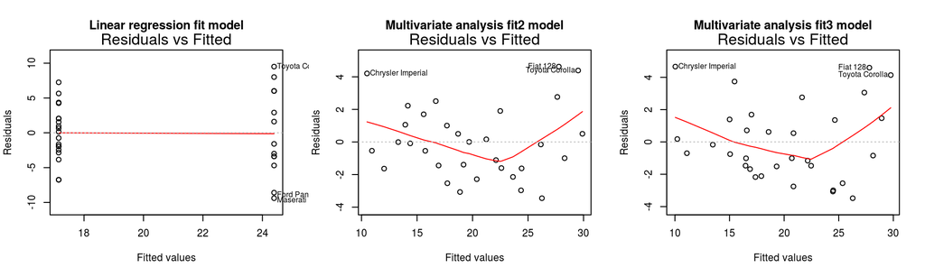

```r
fit2 <- lm (mpg ~ ., mtcars)
par(mfrow = c(1, 3))
plot(fit, which = 1)
title(main = "Linear regression fit model", cex = 1.5)
plot(fit2, which = 1)
title(main = "Multivariate analysis fit2 model", cex = 1.5)
plot(fit3, which = 1)
title(main = "Multivariate analysis fit3 model", cex = 1.5)
```

[output not shown]